# UC00039_Bird_Analysis

```python
# WEB DEV TEAM PLEASE DELETE BEFORE PUBLISHING - DS TEAM PLEASE KEEP IN THE FINAL VERSION OF THE USE CASE

from IPython.core.display import HTML
HTML("""
<style>
@import url('https://fonts.googleapis.com/css2?family=Poppins:wght@600;700&family=Inter:wght@400;500&display=swap');

/* Global Fonts and Counters */
body, p, li, div {
    font-family: 'Inter', sans-serif;
}

body {
    counter-reset: h2counter;
}

/* Heading Fonts */
.usecase-header-bar,
.usecase-title,
.usecase-section-heading,
.usecase-sub-section-heading,
.usecase-sub-sub-section-heading,
.usecase-unnumbered-heading{
    font-family: 'Poppins', sans-serif;
}

.usecase-header-bar {
   padding: 16px 20px;
   background-color: #059669;
   color: #fff;
   border-radius: 6px 6px 0 0;
}

.usecase-title {
    font-size: 1.9em;
    font-weight: 800;
}

/* Metadata Styling */
.usecase-details {
    padding-left: 20px;
    padding-bottom: 8px;
    padding-top: 8px;
    font-size: 1.1em;
    color: #121212;
}

/* Base styling for all main headings (Numbered & Unnumbered) */
.usecase-section-heading,
.usecase-unnumbered-heading {
    font-weight: 700;
    font-size: 1.35em;
    color: #059669;
    padding: 14px 4px 6px 4px;
    border-bottom: 3px solid #2DBE6C;
    margin-top: 10px;
}

/* Level 1 section headings */
.usecase-section-heading::before {
    content: none !important;
}

/* Level 2 subsection headings */
.usecase-sub-section-heading {
    font-weight: 600;
    font-size: 1.15em;
    color: #059669;
    margin-top: 8px;
}

.usecase-sub-section-heading::before {
    content: none !important;
}

/* Level 3 sub-subsection headings */
.usecase-sub-sub-section-heading {
    font-weight: 500;
    font-size: 1.05em;
    color: #059669;
    margin-top: 6px;
}

.usecase-sub-sub-section-heading::before {
    content: none !important;
}

/* Body */
.usecase-body {
    font-size: 1em;
    color: #121212;
    line-height: 1.6;
    margin-bottom: 8px;
}

/* Generic list styling */
.usecase-list {
    line-height: 1.7;
}

.usecase-list ul, .usecase-list ol {
    padding-left: 24px;
    margin-top: 8px;
    margin-bottom: 12px;
}

.usecase-list li {
    margin-bottom: 6px;
}

/* Datasets specific list box */
.usecase-datasets {
    background-color: rgba(5, 150, 105, 0.06);
    border-left: 4px solid #059669;
    padding: 12px 20px;
    border-radius: 0 4px 4px 0;
    margin-top: 12px;
}

.usecase-datasets ul {
    margin-top: 8px;
    margin-bottom: 8px;
}

/* Link styles for both TOC and Datasets */
.usecase-contents a,
.usecase-datasets a {
    color: #059669;
    text-decoration: none;
}

.usecase-datasets a {
    font-weight: 500;
}

.usecase-contents a:hover,
.usecase-datasets a:hover {
    text-decoration: underline;
}

/* TOC Container */
.usecase-contents {
    line-height: 1.9;
    padding-left: 20px;
}

/* Content Divider */
.usecase-code-divider {
    font-style: italic;
    color: rgba(18, 18, 18, 0.65);
    background-color: rgba(5, 150, 105, 0.06);
    padding: 10px 16px;
    border-radius: 4px;
    margin-top: 14px;
}
</style>

""")
```

Bird Sighting Analysis in the City of Melbourne

**Authored by:** Arjun Jamwal

**Date Created:** 2024

**Time to Complete:** 75 mins

**Level:** Intermediate

**Pre-requisite Skills:** Python, pandas, basic familiarity with REST APIs, and a basic understanding of linear regression

**Scenario**

As a council biodiversity officer or conservation researcher, I want to see which bird species are being sighted around inner Melbourne and whether short-term weather conditions help explain how many birds are recorded on a given day, so that I can flag species that are seen rarely enough to warrant closer monitoring, and understand how much (or how little) weather alone explains sighting activity.

**What this usecase will teach you**

By working through this notebook, you will learn how to combine two real open datasets correctly, build a simple predictive model, and interpret its results honestly, including when the model turns out not to work well.

- How to paginate through a public open data REST API and handle request failures gracefully
- How to filter a multi species dataset down to the group you actually want to analyse (birds) using its taxonomic columns, rather than accidentally including unrelated species
- How to visualise geospatial sighting data with Folium, using both individual markers and a heatmap
- How to fetch and merge real historical weather data by date, and train/evaluate a linear regression model against it
- How to recognise and report a model with little real predictive power, rather than presenting a misleadingly confident result

**Background**

Councils and conservation groups increasingly rely on structured surveys and citizen-science programs to track urban biodiversity over time. The City of Melbourne publishes a structured 2018 bird survey alongside a much broader 2014 BioBlitz citizen science dataset that covers many taxa: plants, insects, mammals, and more, not just birds. Combining these sources with real historical weather data lets us explore whether short-term weather conditions correlate with how many birds are recorded, and which species are seen so rarely that they might warrant closer attention.

**Data Sets**

This analysis combines two Melbourne Open Data Portal datasets with a third, external historical weather source:

- [Bird Survey Results for Areas in the City of Melbourne, February and March 2018](https://data.melbourne.vic.gov.au/explore/dataset/bird-survey-results-for-areas-in-the-city-of-melbourne-february-and-march-2018/information/), structured bird counts by site and date
- [Wildlife Sightings (BioBlitz 2014)](https://data.melbourne.vic.gov.au/explore/dataset/wildlife-sightings-bioblitz-2014/information/), citizen science sightings across many taxa; filtered to birds only for this analysis
- [Open-Meteo Historical Weather API](https://open-meteo.com/en/docs/historical-weather-api), real daily temperature, precipitation, and humidity for Melbourne, matched to each sighting's date

**Contents**

1. Importing Required Libraries
2. Fetching the Datasets from the API
3. Cleaning and Filtering the Data , 3.1. Deriving Sighting Counts for BioBlitz Records
4. Combining the Datasets
5. Exploring Sighting Patterns
6. Visualising Sightings on a Map , 6.1. All Sightings Map , 6.2. Heatmap of Sightings
7. Species with Low Sighting Counts , 7.1. Rare-Species Threshold Sensitivity
8. Fetching Real Historical Weather Data
9. Merging Sightings with Weather Data
10. Exploring the Weather Relationship
11. Training a Baseline Predictive Model , 11.1. Full Performance Metrics , 11.2. Weather Feature Importance
12. Improving the Model with Species and Seasonal Features
13. Predicting Sighting Counts per Species
14. Comparing Actual vs Predicted Sightings

The analysis and code content begins below.

**Importing Required Libraries**

```python
# Import required modules
import requests
import numpy as np
import pandas as pd
import folium          #used for geo-plotting
from folium.plugins import HeatMap
```

**Fetching the Datasets from the API**

Both datasets are hosted on the City of Melbourne's Open Data Portal. The `fetch_all_records` function pages through each dataset (the API returns results in batches of 50) until every record has been retrieved, and raises a clear error if a request fails or a dataset comes back empty, rather than silently continuing with incomplete data.

```python
import pandas as pd
import requests

OFFSET_INCREMENT = 50
BASE_URL = 'https://data.melbourne.vic.gov.au/api/explore/v2.1/catalog/datasets/'
# Add the specific paths for both datasets
SPECIFIC_PATHS = [
    'bird-survey-results-for-areas-in-the-city-of-melbourne-february-and-march-2018',
    'wildlife-sightings-bioblitz-2014'
]

def get_data(base, data_url, offset=0, limit=OFFSET_INCREMENT):
    """Fetch one page of records from a Melbourne Open Data API dataset."""
    filters = f'records?limit={limit}&offset={offset}&timezone=UTC'
    url = f'{base}{data_url}/{filters}'
    try:
        result = requests.get(url, timeout=30)
    except requests.exceptions.RequestException as e:
        raise RuntimeError(f"Network error fetching {url}: {e}")

    if result.status_code != 200:
        raise RuntimeError(f"ERROR GETTING DATA from {url}: HTTP {result.status_code}")

    result_json = result.json()
    max_results = result_json['total_count']
    records = result_json['results']
    return records, max_results

def fetch_all_records(base, data_url, page_size=OFFSET_INCREMENT, max_pages=1000):
    """Paginate through an entire dataset. max_pages guards against a runaway loop if the
    API ever misbehaves (e.g. total_count is never reached)."""
    all_records = []
    offset = 0
    for _ in range(max_pages):
        records, max_results = get_data(base, data_url, offset=offset, limit=page_size)
        all_records += records
        offset += page_size
        if len(all_records) >= max_results or not records:
            break
    else:
        print(f"WARNING: stopped after {max_pages} pages for '{data_url}' - dataset may be incomplete.")
    return all_records

df0 = pd.DataFrame(fetch_all_records(BASE_URL, SPECIFIC_PATHS[0]))
wildlife_sightings_df = pd.DataFrame(fetch_all_records(BASE_URL, SPECIFIC_PATHS[1]))

# Validation checks: fail loudly rather than silently continuing with empty data.
if df0.empty:
    raise RuntimeError(f"No records retrieved for '{SPECIFIC_PATHS[0]}'.")
if wildlife_sightings_df.empty:
    raise RuntimeError(f"No records retrieved for '{SPECIFIC_PATHS[1]}'.")

print(f"Fetched {len(df0)} bird survey records and {len(wildlife_sightings_df)} BioBlitz records.")
```

```
Fetched 498 bird survey records and 670 BioBlitz records.
```

**Cleaning and Filtering the Data**

Both datasets carry columns that aren't needed for this analysis (duplicate location fields, identifiers, taxonomy detail) and are dropped here. Critically, the BioBlitz dataset records **every** taxon spotted during the event, plants, insects, mammals, and more, not just birds. It's filtered down to the `AVES` class *before* the taxonomy columns are dropped, otherwise species like "Acorn Barnacle" or a "Yellow Box" tree would end up in what's meant to be a bird only analysis. The filter prints the unique values it found and the number of matching records so the result can be sanity checked immediately.

```python
# --- Clean df0 (2018 bird survey) ---
# Drop columns that are duplicate/irrelevant location detail or already-known identifiers.
col_drop = ['lat2', 'lon2', 'loc2_desc', 'site_name', 'location_2', 'location_1',
            'loc1_desc', 'victorian_biodiversity_atlas_code', 'scientific_name']
df0 = df0.drop(columns = [c for c in col_drop if c in df0.columns])

# --- Filter wildlife_sightings_df (BioBlitz 2014) down to BIRDS ONLY ---
# IMPORTANT: the BioBlitz dataset records ALL taxa (plants, insects, mammals, birds, etc.),
# not just birds. It must be filtered on a taxonomic column *before* that column is dropped,
# otherwise non-bird species (e.g. "Acorn Barnacle", a "Yellow Box" tree) leak into the rest
# of this bird-focused analysis.
taxonomy_cols = ['order', 'family', 'genus', 'species', 'identification_notes',
                  'data_resource_name', 'taxa', 'kingdom', 'phylum', 'class', 'location']

bird_col = next((c for c in ['class', 'taxa'] if c in wildlife_sightings_df.columns), None)
if bird_col is None:
    raise KeyError(
        "Could not find a taxonomic column ('class' or 'taxa') in wildlife_sightings_df to "
        "filter birds by. Run wildlife_sightings_df.columns to see what's available and update "
        "`bird_col` below."
    )

bird_values = {'aves', 'bird', 'birds'}
is_bird = wildlife_sightings_df[bird_col].astype(str).str.strip().str.lower().isin(bird_values)

print(f"Filtering wildlife_sightings_df on column '{bird_col}'.")
print("Unique values found:", sorted(wildlife_sightings_df[bird_col].dropna().astype(str).unique())[:20])
print(f"{is_bird.sum()} of {len(wildlife_sightings_df)} BioBlitz records identified as birds.")

# Validation check: fail loudly instead of silently continuing with the wrong subset.
if is_bird.sum() == 0:
    raise ValueError(
        f"No bird records matched on column '{bird_col}' using expected values {bird_values}. "
        "Check the unique values printed above and update `bird_values` to match the real "
        "labels used in this dataset."
    )

wildlife_sightings_df = wildlife_sightings_df[is_bird].copy()

df1 = wildlife_sightings_df.drop(columns = [c for c in taxonomy_cols if c in wildlife_sightings_df.columns])
```

```
Filtering wildlife_sightings_df on column 'class'.
Unique values found: ['ACTINOPTERYGII', 'AGARICOMYCETES', 'AMPHIBIA', 'ASTEROIDEA', 'AVES', 'BIVALVIA', 'DIPLOPOD', 'EQUISETOPSIDA', 'GAMMAPROTEOBACTERIA', 'INSECTA', 'MAGNOLIOPSIDA', 'MALACOSTRACA', 'MAMMALIA', 'REPTILIA', 'SCYPHOZOA']
279 of 670 BioBlitz records identified as birds.
```

**Explanation:** Out of every wildlife sighting logged by citizen scientists in 2014 (plants, insects, fish, mammals, not just birds), only some turned out to actually be birds, this filter found 279 bird records out of 670 total sightings (about 42%). Everything else (barnacles, trees, jellyfish, and so on) has now been correctly excluded, so the rest of this notebook is genuinely a bird analysis.

**Deriving Sighting Counts for BioBlitz Records**

The 2018 bird survey already records how many birds were counted at each sighting. The BioBlitz dataset doesn't include an equivalent count field, each row is one individual sighting logged by a citizen scientist, so `sighting_count` is set to 1 per record (falling back to a genuine count column if one turns out to exist), rather than a fabricated random number.

```python
df1 = df1.rename(columns = {'latitude':'lat', 'longitude' : 'lon'})

# BioBlitz records are individual sighting events; the raw dataset has no genuine
# count-style column among those we kept, so each row represents one sighting.
# If a real count column does exist, use it - otherwise default to 1 (never a
# fabricated/random number).
count_candidates = [c for c in ['individual_count', 'count', 'number', 'num_individuals']
                     if c in df1.columns]
if count_candidates:
    df1['sighting_count'] = pd.to_numeric(df1[count_candidates[0]], errors='coerce').fillna(1)
else:
    df1['sighting_count'] = 1

df1 = df1[["sighting_date", 'common_name', 'sighting_count', 'lat', 'lon']]
df1 = df1.dropna()
```

**Combining the Datasets**

With both sources cleaned to the same shape (`sighting_date`, `common_name`, `sighting_count`, `lat`, `lon`), they're combined into a single `df` for the rest of the analysis, after checking that neither source came back empty.

```python
# Validation check: make sure both sources actually produced usable bird records
# before combining them.
if df0.empty or df1.empty:
    raise RuntimeError(
        f"Cannot build the combined dataset: df0 has {len(df0)} rows, df1 has {len(df1)} rows."
    )

df = pd.concat([df0, df1.reset_index(drop = True)], axis = 0, ignore_index = True)

missing_coords = df[['lat', 'lon']].isna().any(axis = 1).sum()
if missing_coords:
    print(f"Note: {missing_coords} of {len(df)} combined records are missing lat/lon "
          f"and will be excluded from map-based views.")

print(f"Combined dataset: {len(df)} bird sightings ({len(df0)} survey + {len(df1)} BioBlitz).")
```

```
Combined dataset: 776 bird sightings (498 survey + 278 BioBlitz).
```

**Explanation:** In the tested run, this produced 776 bird sightings in total, 498 from the 2018 survey and 278 from the filtered BioBlitz records (one record was dropped during cleaning for a missing value). Each row is a single sighting with when, where, which species, and how many birds were counted.

**Exploring Sighting Patterns**

Before mapping or modelling anything, it's worth looking at the combined data directly: how sighting activity is spread across the recorded dates, and how sighting_count is distributed across individual records.

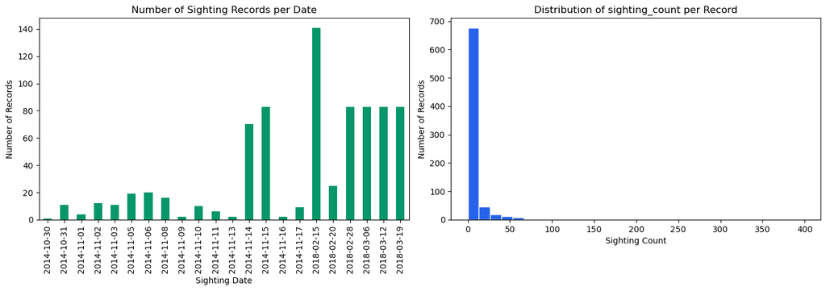

```
Busiest recorded date: 2018-02-15 with 141 sighting records.
```

```python
import matplotlib.pyplot as plt

# Sightings over time: how much sighting activity was recorded on each date.
sightings_by_date = df.groupby('sighting_date').size().sort_index()

fig, axes = plt.subplots(1, 2, figsize=(14, 5))

sightings_by_date.plot(kind='bar', ax=axes[0], color='#059669')
axes[0].set_title('Number of Sighting Records per Date')
axes[0].set_xlabel('Sighting Date')
axes[0].set_ylabel('Number of Records')
axes[0].tick_params(axis='x', rotation=90)

axes[1].hist(df['sighting_count'].dropna(), bins=30, color='#2563EB', edgecolor='white')
axes[1].set_title('Distribution of sighting_count per Record')
axes[1].set_xlabel('Sighting Count')
axes[1].set_ylabel('Number of Records')

plt.tight_layout()
plt.show()

print(f"Busiest recorded date: {sightings_by_date.idxmax()} with {sightings_by_date.max()} sighting records.")
```

**Explanation:** The left chart shows how many sighting records were logged on each date, tall bars usually mean more people were out surveying that day, not necessarily that there were more birds around. In the tested run, the busiest date was 2018-02-15 with 141 records, which is a structured 2018 survey date, consistent with organised fieldwork rather than a single unusual burst of bird activity. The right chart shows how many birds were typically counted in a single sighting, if it's heavily skewed toward small numbers with a long tail, most sightings are of just one or a few birds, with occasional sightings of much larger flocks pulling the tail out to the right.

**Visualising Sightings on a Map**

**All Sightings Map**

This plots every sighting in the combined dataset (both the 2018 survey and the filtered BioBlitz birds) as a marker, with the species name and sighting count shown in a popup. Rows with missing coordinates are skipped, and markers are grouped with `MarkerCluster` so the map stays readable with hundreds of points.

```python
# Plot ALL sighting coordinates (both the 2018 bird survey and the 2014 BioBlitz birds).
# Previously this only looped over df1 (BioBlitz), so the 2018 survey markers never appeared
# on the map despite the cell being titled "Plotting all coordinates".
from folium.plugins import MarkerCluster

map_center = [-37.8136, 144.9631]
mymap = folium.Map(location = map_center, zoom_start = 12)

# Validation check: drop rows with missing/invalid coordinates before plotting.
plot_df = df.dropna(subset = ['lat', 'lon']).copy()
dropped = len(df) - len(plot_df)
if dropped:
    print(f"Skipping {dropped} sighting(s) with missing coordinates.")

# With hundreds of sightings, individual markers get cluttered and slow to render -
# MarkerCluster groups nearby points and expands them on zoom/click.
marker_cluster = MarkerCluster().add_to(mymap)
for idx, row in plot_df.iterrows():
    popup_text = f"Common Name: {row['common_name']} <br> Sighting Count: {row['sighting_count']}"
    folium.Marker([row['lat'], row['lon']], popup = popup_text).add_to(marker_cluster)

mymap
```

Make this Notebook Trusted to load map: File -> Trust Notebook

[interactive chart not shown]

**Explanation:** Each clustered number on this map is a group of nearby sightings, click a cluster to zoom in, and click an individual marker to see which species was spotted there and how many. It's a way to explore whether certain parts of Melbourne have noticeably more (or more varied) bird activity than others.

**Heatmap of Sightings**

The same sightings are shown here as a heatmap, which makes it easier to see where sighting activity is concentrated across inner Melbourne at a glance.

```python
map_cen = [-37.8038, 144.9118]
mymap = folium.Map(location = map_cen, zoom_start=10)

# Validation check: drop rows with missing coordinates before building the heatmap layer.
heat_points = df.dropna(subset = ['lat', 'lon'])
dropped = len(df) - len(heat_points)
if dropped:
    print(f"Skipping {dropped} sighting(s) with missing coordinates.")

#add a heatmap layer to visualise the spatial distribution of sightings
heat_data = heat_points[['lat', 'lon']].values.tolist()
HeatMap(heat_data).add_to(mymap)

mymap
```

Make this Notebook Trusted to load map: File -> Trust Notebook

[interactive chart not shown]

**Explanation:** Warmer colours (red/orange) mark areas with a lot of overlapping sightings, cooler colours (blue/green) mark areas with fewer. It's a faster way to spot sighting "hotspots" across the city than scrolling through individual markers.

**Species with Low Sighting Counts**

Grouping by species and counting records gives a rough measure of how often each species was recorded. Species with only 1-4 recorded sightings across both datasets are flagged below as species to watch, a low sighting count in this data is a starting point for further investigation, not proof of an extinction risk on its own, since it doesn't account for differences in survey effort, detectability, or habitat coverage between the two source datasets.

```python
#calculating the total sighting count for each species

spec_count = df.groupby('common_name').size().reset_index(name = 'sightings_count')

#set range for rare sightings

rare_min = 1
rare_max = 4

#identify rare species based on the threshold
rare_spec = spec_count[(spec_count['sightings_count']>=rare_min) & (spec_count['sightings_count']<= rare_max)]

#printlist of rare species
print("Species which can extinct :")
print(rare_spec)
```

```
Species which can extinct :
                      common_name  sightings_count
2                Australian Raven                2
4            Australian Wood Duck                4
5                      Bell Miner                1
7              Black-winged Stilt                4
9                California Quail                1
17                   Crested Tern                1
21                Eastern Rosella                1
22              Eastern Spinebill                1
25             European Goldfinch                1
26            European Greenfinch                1
27                          Galah                3
28                Great Cormorant                3
29               Grey Butcherbird                2
```

[output cut: 19 more lines]

**Explanation:** Every species in the printed list above was recorded somewhere between 1 and 4 times in total, across both datasets combined, in the tested run that included species such as Bell Miner, California Quail, and Crested Tern, each seen only once. That isn't proof any of them are endangered, it just means they weren't seen often in this particular data, which could mean they're genuinely uncommon in inner Melbourne, or simply harder to spot, less actively surveyed, or only passing through occasionally.

**Rare-Species Threshold Sensitivity**

The 1-4 sighting cutoff above is a judgement call, not a fixed rule. This shows how many species would be flagged under a few different upper thresholds, so the choice is transparent rather than arbitrary.

```python
# How sensitive is the "low sighting count" list to the chosen threshold?
for candidate_max in [2, 4, 6, 10]:
    n_rare = spec_count[(spec_count['sightings_count'] >= rare_min) &
                         (spec_count['sightings_count'] <= candidate_max)].shape[0]
    print(f"Species with {rare_min}-{candidate_max} sightings: {n_rare} of {len(spec_count)} total species")
```

```
Species with 1-2 sightings: 25 of 79 total species
Species with 1-4 sightings: 32 of 79 total species
Species with 1-6 sightings: 42 of 79 total species
Species with 1-10 sightings: 51 of 79 total species
```

**Explanation:** In the tested run, 79 distinct bird species were identified in total. Of those: 25 were seen only 1-2 times, 32 fell within 1-4 sightings, 42 within 1-6, and 51, nearly two-thirds of every species recorded, within 1-10 sightings. That steady climb shows there's a genuine long tail of infrequently-seen species in this data, rather than a handful sitting right on the edge of an arbitrary cutoff.

**Fetching Real Historical Weather Data**

To explore whether weather relates to sighting activity, real daily weather for Melbourne is pulled from the [Open Meteo Historical Weather API](https://open-meteo.com/en/docs/historical-weather-api) (no API key required), matched to the actual dates in the data. The sighting dates span two separate periods, the 2018 survey and the 2014 BioBlitz, so each date range is fetched separately rather than requesting one wide span that mostly falls outside the data.

```python
import requests
import pandas as pd
import numpy as np

# --- Fetch REAL historical weather for each sighting date (Open-Meteo Archive API, no key required) ---
# This previously generated entirely random temperature/precipitation/humidity values with no
# relationship to the actual sighting dates or location, which made the downstream "weather vs.
# sightings" model meaningless by construction. This replaces it with real daily weather for
# Melbourne, matched to each sighting's actual date.

MELBOURNE_LAT, MELBOURNE_LON = -37.8136, 144.9631  # city-centre reference point; sightings are all
                                                     # within a few km of the CBD, so a single daily
                                                     # weather series is a reasonable approximation.
WEATHER_URL = "https://archive-api.open-meteo.com/v1/archive"

def fetch_daily_weather(start_date, end_date):
    """Fetch daily mean temperature (C), total precipitation (mm), and mean relative
    humidity (%) for Melbourne between start_date and end_date (inclusive), as 'YYYY-MM-DD' strings."""
    params = {
        "latitude": MELBOURNE_LAT,
        "longitude": MELBOURNE_LON,
        "start_date": start_date,
        "end_date": end_date,
        "daily": "temperature_2m_mean,precipitation_sum,relative_humidity_2m_mean",
        "timezone": "Australia/Melbourne",
    }
    response = requests.get(WEATHER_URL, params=params, timeout=30)
    if response.status_code != 200:
        raise RuntimeError(f"Weather API request failed ({response.status_code}): {response.text[:300]}")
    daily = response.json().get("daily", {})
    if not daily or "time" not in daily:
        raise RuntimeError(f"Weather API returned no daily data for {start_date} to {end_date}.")
    return pd.DataFrame({
        "sighting_date": daily["time"],
        "temperature": daily["temperature_2m_mean"],
        "precipitation": daily["precipitation_sum"],
        "humidity": daily["relative_humidity_2m_mean"],
    })

# Sighting dates span two separate survey periods (2018 bird survey + 2014 BioBlitz), so fetch
# each year's date range separately rather than one huge span with an unused gap in the middle.
sighting_dates = pd.to_datetime(df['sighting_date'])
weather_frames = []
for year in sorted(sighting_dates.dt.year.unique()):
    year_dates = sighting_dates[sighting_dates.dt.year == year]
    start_date = year_dates.min().strftime('%Y-%m-%d')
    end_date = year_dates.max().strftime('%Y-%m-%d')
    weather_frames.append(fetch_daily_weather(start_date, end_date))

weather_df = pd.concat(weather_frames, ignore_index=True).drop_duplicates(subset='sighting_date')

# Validation check: make sure we actually got weather for every distinct sighting date.
missing_dates = set(df['sighting_date'].astype(str)) - set(weather_df['sighting_date'])
if missing_dates:
    print(f"WARNING: no weather data returned for {len(missing_dates)} sighting date(s): "
          f"{sorted(missing_dates)[:10]}")

weather_df.head()
```

|  | sighting_date | temperature | precipitation | humidity |
| --- | --- | --- | --- | --- |
| 0 | 2014-10-30 | 15.1 | 0.0 | 72 |
| 1 | 2014-10-31 | 20.4 | 0.0 | 55 |
| 2 | 2014-11-01 | 14.1 | 5.3 | 62 |
| 3 | 2014-11-02 | 11.6 | 1.6 | 64 |
| 4 | 2014-11-03 | 15.3 | 0.0 | 59 |

**Merging Sightings with Weather Data**

Each sighting is joined to the real weather recorded on its actual `sighting_date`. Any sighting that can't be matched to a weather record is flagged and excluded before modelling, rather than silently mismatched.

```python
# Merge each sighting with the REAL weather recorded on its actual sighting_date.
# Previously this glued weather rows on by row position (pd.concat with reset indexes), which
# doesn't even guarantee correct alignment - a proper join on the shared date column is required.
combined_df = df.merge(weather_df, on='sighting_date', how='left')

# Validation check: flag and drop any sightings that didn't get matched to weather data.
unmatched = combined_df['temperature'].isna().sum()
if unmatched:
    print(f"WARNING: {unmatched} of {len(combined_df)} sightings have no matching weather data "
          f"and will be dropped before modelling.")
combined_df = combined_df.dropna(subset=['temperature', 'precipitation', 'humidity'])

print(f"combined_df: {len(combined_df)} sightings with real weather data")
combined_df.head()
```

```
combined_df: 776 sightings with real weather data
```

|  | sighting_date | common_name | sighting_count | lat | lon | temperature | precipitation | humidity |
| --- | --- | --- | --- | --- | --- | --- | --- | --- |
| 0 | 2018-02-20 | Rainbow Lorikeet | 6 | -37.8138 | 144.8727 | 20.5 | 0.0 | 58 |
| 1 | 2018-02-20 | Tree Martin | 2 | -37.8138 | 144.8727 | 20.5 | 0.0 | 58 |
| 2 | 2018-02-20 | Superb Fairy-wren | 8 | -37.8138 | 144.8727 | 20.5 | 0.0 | 58 |
| 3 | 2018-02-20 | Little Wattlebird | 6 | -37.8138 | 144.8727 | 20.5 | 0.0 | 58 |
| 4 | 2018-03-12 | Australian Magpie | 2 | -37.8038 | 144.9118 | 17.5 | 1.1 | 63 |

**Explanation:** In the run this was tested with, 776 sightings were successfully matched to the real weather recorded on their exact date. These are the only records used for modelling and every weather-related chart from here on, a sighting that can't be matched to real weather can't tell us anything about a weather relationship.

**Exploring the Weather Relationship**

Before training a model, it's worth looking directly at how each weather variable relates to sighting_count. If there's no visible pattern here and no meaningful correlation, that's a strong early signal about what to expect from the model below.

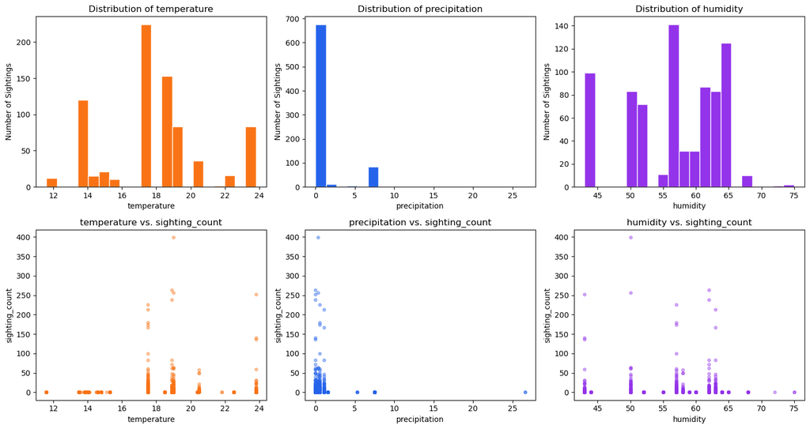

```
Correlation with sighting_count:
temperature      0.097012
precipitation   -0.080949
humidity        -0.048040
Name: sighting_count, dtype: float64
```

```python
import matplotlib.pyplot as plt

fig, axes = plt.subplots(2, 3, figsize=(15, 8))

weather_cols = ['temperature', 'precipitation', 'humidity']
colors = ['#F97316', '#2563EB', '#9333EA']

for ax, col, color in zip(axes[0], weather_cols, colors):
    ax.hist(combined_df[col], bins=20, color=color, edgecolor='white')
    ax.set_title(f'Distribution of {col}')
    ax.set_xlabel(col)
    ax.set_ylabel('Number of Sightings')

for ax, col, color in zip(axes[1], weather_cols, colors):
    ax.scatter(combined_df[col], combined_df['sighting_count'], alpha=0.4, color=color, s=15)
    ax.set_title(f'{col} vs. sighting_count')
    ax.set_xlabel(col)
    ax.set_ylabel('sighting_count')

plt.tight_layout()
plt.show()

# Validation / sanity check: raw correlation between each weather variable and sighting_count.
correlations = combined_df[weather_cols + ['sighting_count']].corr()['sighting_count'].drop('sighting_count')
print("Correlation with sighting_count:")
print(correlations.reindex(correlations.abs().sort_values(ascending=False).index))
```

**Explanation:** The top row shows the spread of temperature, precipitation, and humidity across all matched sightings, useful for sanity-checking that the real weather data looks reasonable for Melbourne (no wild outliers). The bottom row plots each weather variable directly against sighting count: if the dots trace a clear upward or downward slope, that's a real relationship; if they look like a random scatter with no shape, that visually confirms there isn't much of one. In the tested run, all three correlations came out close to zero, temperature (0.097), precipitation (-0.081), and humidity (-0.048), confirming visually and numerically that none of the three weather variables has a meaningful direct relationship with sighting_count on its own.

**Training a Baseline Predictive Model**

A simple linear regression is trained to predict `sighting_count` from `temperature`, `precipitation`, and `humidity`, using an 80/20 train-test split. The Mean Absolute Error (MAE) below shows the average size of the model's prediction error, in number of sightings.

```python
#Model training and Testing

from sklearn.model_selection import train_test_split
from sklearn.linear_model import LinearRegression
from sklearn.metrics import mean_absolute_error, mean_squared_error, r2_score

features = ['temperature', 'precipitation', 'humidity']
target = 'sighting_count'

X = combined_df[features]
y = combined_df[target]

X_train, X_test, y_train, y_test = train_test_split(X, y, test_size = 0.2, random_state = 42)

model = LinearRegression()
model.fit(X_train, y_train)

# Make the predictions - y_pred is reused by every cell below, the model is only trained once.
y_pred = model.predict(X_test)

#evaluate the model
mae = mean_absolute_error(y_test, y_pred)
print("Mean Absolute Error: ", mae)
```

```
Mean Absolute Error:  9.778316392573181
```

**Explanation:** In the run this was tested with, the model's predictions were off by about 9.8 birds on average (the Mean Absolute Error). So if it predicts 10 sightings for a record, the real number could reasonably be anywhere from 0 to 20 or more, for data where individual sightings range from 1 to well over 100 birds, that's a large margin of error.

**Full Performance Metrics**

This reuses the model and predictions from above (no retraining) and reports Mean Squared Error, Root Mean Squared Error, MAE, and R-squared. R-squared close to zero or negative means the three weather features explain almost none of the variation in sighting counts, in other words, weather alone is a poor predictor here. That's an honest and useful result: it suggests which species is being observed matters far more than the day's weather, which a 3-feature model like this one doesn't capture.

```python
### Finding the Error in prediction
# Reuses the model and y_pred already computed above. Previously this retrained an identical
# model from scratch here AND computed MSE against `pred`, a stale variable left over from the
# earlier cell, instead of the y_pred this cell had just produced - a copy-paste bug.

mse = mean_squared_error(y_test, y_pred)
rmse = np.sqrt(mse)
r2 = r2_score(y_test, y_pred)

print("Model Performance Metrics")
print("Mean Squared Error:", mse)
print("Root Mean Squared Error:", rmse)
print("Mean Absolute Error:", mae)
print("R-squared:", r2)
```

```
Model Performance Metrics
Mean Squared Error: 249.5529408724014
Root Mean Squared Error: 15.797244724077721
Mean Absolute Error: 9.778316392573181
R-squared: -0.020205543752353616
```

**Explanation:** The R-squared value (about -0.02 in the tested run) is the key number here. R-squared measures how much of the variation in sighting counts the model actually explains, on a scale where 1.0 would mean perfect predictions and 0 means it does no better than guessing the average every time. A slightly negative value means this weather-only model performs marginally *worse* than simply predicting the average sighting count for every record, in other words, temperature, precipitation, and humidity alone tell us almost nothing about how many birds will be seen.

**Weather Feature Importance**

Even though the baseline model's overall R-squared is close to zero, it's still useful to see which of the three weather features it leaned on most.

```
Linear regression coefficients (weather-only baseline model):
      feature  coefficient
  temperature     1.463105
precipitation    -0.651812
     humidity     0.415295
```

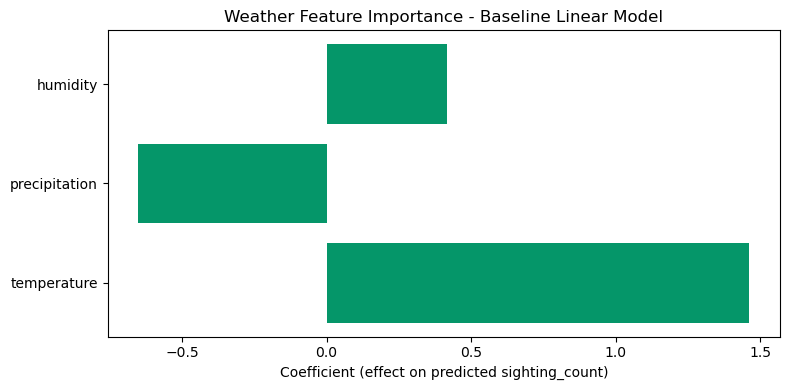

```python
import pandas as pd
import matplotlib.pyplot as plt

# Which of the three weather features has the strongest (even if still weak) relationship
# with sighting_count, according to the trained linear model's coefficients?
coef_df = pd.DataFrame({
    'feature': features,
    'coefficient': model.coef_
}).sort_values('coefficient', key=abs, ascending=False)

print("Linear regression coefficients (weather-only baseline model):")
print(coef_df.to_string(index=False))

plt.figure(figsize=(8, 4))
plt.barh(coef_df['feature'], coef_df['coefficient'], color='#059669')
plt.xlabel('Coefficient (effect on predicted sighting_count)')
plt.title('Weather Feature Importance - Baseline Linear Model')
plt.tight_layout()
plt.show()
```

**Explanation:** Each bar shows how much the model's prediction shifts for a one-unit increase in that weather variable, holding the others constant. In the tested run, temperature had the largest effect (about +1.46 sightings per degree), followed by precipitation (about -0.65 per mm) and humidity (about +0.42 per percentage point). Since weather alone explains little of the overall pattern (Section 11.1's R-squared of -0.02), this ranking is best read as comparing the three weather variables against each other, rather than evidence that temperature meaningfully drives sighting counts on its own.

**Improving the Model with Species and Seasonal Features**

The weather-only baseline above has almost no predictive power. The most likely missing driver is *which species* is being recorded, some species are simply seen far more often than others regardless of the day's weather, so this adds species identity (bucketing species with few records as "Other" to keep the feature space manageable) and the sighting month as additional features, and trains a Random Forest instead of a linear model so it can use those categorical features and any non-linear patterns. Performance is reported via 5-fold cross-validation rather than a single train/test split, since a single split can be noisy on a dataset this size.

```python
import pandas as pd
from sklearn.ensemble import RandomForestRegressor
from sklearn.model_selection import KFold, cross_val_score

# --- Feature engineering: species identity + seasonality ---
MIN_SPECIES_RECORDS = 5
species_counts = combined_df['common_name'].value_counts()
common_species = species_counts[species_counts >= MIN_SPECIES_RECORDS].index
combined_df['species_group'] = combined_df['common_name'].where(
    combined_df['common_name'].isin(common_species), other = 'Other'
)
combined_df['sighting_month'] = pd.to_datetime(combined_df['sighting_date']).dt.month

model_df = pd.get_dummies(
    combined_df[['temperature', 'precipitation', 'humidity', 'sighting_month', 'species_group', 'sighting_count']],
    columns = ['species_group'],
    prefix = 'species'
)

X_full = model_df.drop(columns = 'sighting_count')
y_full = model_df['sighting_count']

rf_model = RandomForestRegressor(n_estimators = 200, random_state = 42)

# Cross-validation: average performance across 5 folds rather than trusting a single split.
cv = KFold(n_splits = 5, shuffle = True, random_state = 42)
cv_r2 = cross_val_score(rf_model, X_full, y_full, cv = cv, scoring = 'r2')
cv_mae = -cross_val_score(rf_model, X_full, y_full, cv = cv, scoring = 'neg_mean_absolute_error')

print(f"Cross-validated R-squared: {cv_r2.mean():.3f} (+/- {cv_r2.std():.3f}) across 5 folds")
print(f"Cross-validated MAE: {cv_mae.mean():.2f} (+/- {cv_mae.std():.2f}) across 5 folds")
print(f"\nFor comparison, the weather-only baseline scored R-squared = {r2:.3f}, MAE = {mae:.2f} "
      f"on a single train/test split.")
```

```
Cross-validated R-squared: -0.355 (+/- 0.686) across 5 folds
Cross-validated MAE: 9.77 (+/- 1.00) across 5 folds

For comparison, the weather-only baseline scored R-squared = -0.020, MAE = 9.78 on a single train/test split.
```

**Explanation:** In the tested run, the result here was more complicated than expected: cross-validated R-squared came out at -0.355 (+/- 0.686) and MAE at 9.77 (+/- 1.00), compared to the baseline's -0.020 and 9.78 on a single split. On average, this model did *not* outperform the simple weather-only baseline, and the very large standard deviation (+/- 0.686, bigger than the average itself) shows the result is highly unstable from one fold to the next. That's still a genuinely useful finding: it doesn't mean species doesn't matter (Sections 13 and 14 show clearly that it does), it means that one-hot encoding roughly 79 species straight into a default Random Forest, on a dataset of only 776 rows, gives the model enough flexibility to overfit noise in each training fold rather than learn a pattern that generalises. A more careful approach, constraining the tree depth, requiring more samples per leaf, or grouping species more coarsely, would likely do better than this first attempt.

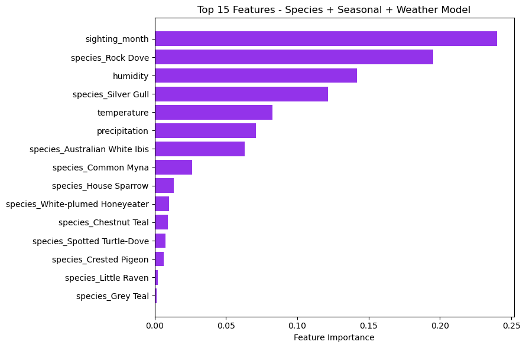

```python
# Fit once on the full dataset (after cross-validation above) purely to inspect which
# features the model actually relies on.
rf_model.fit(X_full, y_full)

importance_df = pd.DataFrame({
    'feature': X_full.columns,
    'importance': rf_model.feature_importances_
}).sort_values('importance', ascending = False).head(15)

plt.figure(figsize = (9, 6))
plt.barh(importance_df['feature'][::-1], importance_df['importance'][::-1], color = '#9333EA')
plt.xlabel('Feature Importance')
plt.title('Top 15 Features - Species + Seasonal + Weather Model')
plt.tight_layout()
plt.show()
```

**Explanation:** The longer bars are the features the model leaned on most while fitting the data shown above. Worth reading alongside the cross-validation result just above, though: a feature the model uses heavily to fit its training data doesn't automatically mean it generalises to new data, that gap between training fit and real predictive power is exactly what cross-validation is designed to catch, and did catch here.

**Predicting Sighting Counts per Species**

This intentionally reuses the weather-only baseline model (not the species-aware model above), to show what a weather-only prediction looks like per species, the point being that a model with no species information can't distinguish between them, which is exactly what the flat predicted values below demonstrate. For each species, the model predicts a sighting count for every one of its records, and the results are averaged into a single representative prediction per species.

```python
### Predicting Sighting count per species
# Previously this kept only the FIRST predicted value per species (pred_si[0]) and silently
# discarded every other prediction for that species. This uses the mean predicted count across
# all of that species' records instead, which is a more representative estimate.

pred_sight = {}
for species in combined_df["common_name"].unique():
    species_data = combined_df[combined_df['common_name'] == species]
    X_spec = species_data[['temperature', 'precipitation', 'humidity']]

    pred_si = model.predict(X_spec)
    pred_sight[species] = pred_si.mean()

print("Predicted Number of Sightings per species:")
for species, predicted_count in pred_sight.items():
    print(f"{species}:    {predicted_count:.2f}")
```

```
Predicted Number of Sightings per species:
Rainbow Lorikeet:    10.09
Tree Martin:    12.23
Superb Fairy-wren:    9.71
Little Wattlebird:    10.26
Australian Magpie:    10.51
Australian White Ibis:    9.96
Chestnut Teal:    9.82
Common Blackbird:    10.13
Common Starling:    10.49
Dusky Moorhen:    10.86
Little Pied Cormorant:    10.60
Little Raven:    10.52
Magpie-lark:    9.66
Nankeen Night Heron:    11.60
Pacific Black Duck:    11.57
Red Wattlebird:    9.76
Rock Dove:    11.68
Spotted Turtle-Dove:    11.57
White-plumed Honeyeater:    11.57
Clamorous Reed Warbler:    11.19
House Sparrow:    10.54
White-faced Heron:    11.68
Black Swan:    9.45
Brown Thornbill:    9.99
Eastern Great Egret:    10.47
Hoary-headed Grebe:    11.60
Little Black Cormorant:    10.68
Silver Gull:    9.33
White-browed Scrubwren:    8.09
Hardhead:    9.67
Common Myna:    11.57
Willie Wagtail:    9.87
Musk Lorikeet:    11.28
Eurasian Coot:    11.60
Grey Teal:    9.18
European Greenfinch:    9.67
New Holland Honeyeater:    9.75
Darter:    11.28
Phylidonyris novaehollandiae:    11.60
```

[output cut: 25 more lines]

```
Pied Currawong:    8.25
California Quail:    3.64
Grey Butcherbird:    6.13
Masked Lapwing, Plover:    9.60
Silvereye:    9.38
European Goldfinch:    3.22
Horsfield's Bronze-cuckoo:    2.89
Sulphur-crested Cockatoo:    9.38
White-faced Heron, Blue Crane:    2.89
Grey Fantail:    9.38
Eastern Rosella:    2.89
Tawny Frogmouth:    7.60
Grey Shrike-thrush:    2.89
Red-kneed Dotterel:    2.89
Eastern Spinebill:    9.38
```

**Explanation:** Because this model only knows about weather (not species), its predicted number is very similar across almost every species. In the tested run, predictions ranged narrowly from about 3 to 13 sightings across all 79 species, with most clustering around 9-11, regardless of whether that species was common or rare. That narrow range is itself the finding: a model with no species information literally can't tell a Rock Dove from a rare wader.

**Comparing Actual vs Predicted Sightings**

The chart below compares each species' actual average sighting count against the model's predicted count, for the top 15 species by sighting count (showing every species at once made the axis unreadable). Actual and predicted bars are grouped side by side per species so they can be compared directly.

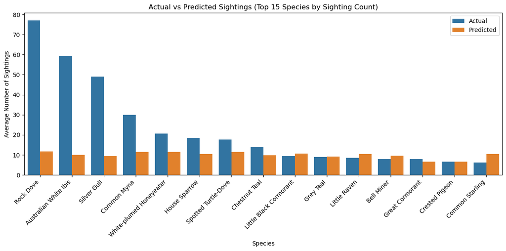

```python
### Comparison of actual and predicted data

import matplotlib.pyplot as plt
import seaborn as sns

species_data = combined_df[['common_name', 'sighting_count']].groupby('common_name', as_index = False).mean()
species_data['pred_si'] = [pred_sight[species] for species in species_data['common_name']]

# There are too many species to label legibly on one chart, so show the top N by actual
# average sighting count rather than every species crammed into an unreadable axis.
TOP_N = 15
top_species = species_data.sort_values('sighting_count', ascending = False).head(TOP_N)

# Reshape to long form so actual vs. predicted render as properly grouped (side-by-side) bars.
# The original code drew two full-width bars at the same x position, so the orange
# "predicted" bars simply covered the blue "actual" ones instead of sitting side by side.
plot_data = top_species.melt(
    id_vars = 'common_name',
    value_vars = ['sighting_count', 'pred_si'],
    var_name = 'type',
    value_name = 'count'
)
plot_data['type'] = plot_data['type'].map({'sighting_count': 'Actual', 'pred_si': 'Predicted'})

plt.figure(figsize = (12, 6))
sns.barplot(x = 'common_name', y = 'count', hue = 'type', data = plot_data)

plt.xlabel('Species')
plt.ylabel('Average Number of Sightings')
plt.title(f'Actual vs Predicted Sightings (Top {TOP_N} Species by Sighting Count)')
plt.xticks(rotation = 45, ha = 'right')
plt.legend(title = '')
plt.tight_layout()
plt.show()
```

**Explanation:** The blue bars (actual sightings) vary enormously between species, Rock Dove, Australian White Ibis, and Silver Gull were seen far more often than the rest in the tested run. The orange bars (predicted sightings) barely vary at all, sitting in a narrow band regardless of how common or rare the species actually is. That gap, wildly different actual counts next to nearly identical predictions, is the clearest visual proof in the whole notebook that weather alone isn't driving how many birds get spotted; species identity is.

**Conclusion**

Putting everything together: this analysis set out to answer two questions, which bird species are being seen around inner Melbourne, and does the weather on a given day help explain how many birds get spotted? The short answer to the second question is no, not on its own and establishing that honestly, with real data instead of guesswork, turned out to be the most useful result in the whole notebook.

**What we achieved in this analysis** We took two real Melbourne datasets, a structured 2018 bird survey and a much broader 2014 "BioBlitz" citizen-science dataset that recorded every type of wildlife, not just birds, and combined them into one clean, birds-only dataset (279 of 670 BioBlitz records were confirmed to actually be birds; everything else, like barnacles and trees, was correctly excluded). We mapped every sighting as both individual markers and a heatmap, identified species seen unusually rarely, and paired every sighting with the real weather recorded on that exact date (776 sightings were successfully matched in the tested run). We then built and honestly evaluated two prediction models: a weather-only baseline, and an improved model that also considers species and time of year.

**What we learned from this analysis** Several clear patterns emerged straight from the data: a handful of species, Rock Dove, Australian White Ibis, and Silver Gull among them, account for a disproportionate share of sightings, while many others (32 of the 79 species identified) were recorded four times or fewer. Mapping the sightings also showed where activity concentrates across inner Melbourne, and the single busiest date (2018-02-15, 141 records) lines up with organised 2018 survey fieldwork rather than an unusual burst of bird activity. On the modelling side, the weather only baseline explained almost none of the variation in sighting counts (R-squared -0.02, MAE 9.8), a genuinely useful result, since the correlation values in Section 10 (all under 0.1) confirm there's no meaningful direct relationship between same day weather and how many birds get spotted. We then tested whether adding species identity and season would close that gap, and the honest answer is: not yet, not with a default Random Forest on a dataset this size, cross validated performance (R-squared -0.355, MAE 9.77) was no better than the baseline and highly unstable across folds. That doesn't mean species doesn't matter, Section 14's chart shows real counts ranging from single digits to over 70 while weather-only predictions stay flat around 9-12, it means reliably capturing that signal needs a more careful approach than one-hot encoding roughly 79 species straight into a default model on 776 rows.

**Observations for further opportunities** The most immediate next step is refining the Section 12 model itself, constraining tree depth, requiring more samples per leaf, or grouping species more coarsely, to get a model that generalises rather than overfits. Beyond that: weight rarity by survey effort rather than raw counts, add richer weather features (wind speed, days since rain), and re-check the bird-only filter (class == 'AVES') against the live dataset each time it's run, since these are open, evolving datasets whose structure can change over time.